# Final project - Text Analytics on Airbnb NYC dataset

In this part, we moved onto text analytics to reveal how listing owners portray their places and visitors describe their experiences and express their feelings after staying at a specific venue of Airbnb. Listing summary and amenities description provide a good clue to for the former question and reviews comments shed insights on the latter question. The use of adjective words are indicative of positive and negative sentiment of visitors’ experiences. Moreover, we also investigated users’ behviours on sharing their experiecens as well as change of user behaviour over time on Airbnb based on the length of reviews in the combination of different NYC boroughs, room-types or rating category.

Text analytics on Airbnb NYC dataset mainly focused on the three areas: listings summary, amenities description and review comments. The frist section is the description of preprocessing, following by the analysis of data quality and the interesting questions to address in each area. Following are the questions we asked to understand user behaviours and experiences on Airbnb:

- Which adjective words appear most frequently in listing summary?
- Are words of summary in each rating category the same?
- What are the most frequent amenities words?
- Which adjective words appear in high-rating or low-rating reviews?
- Is the length of reviews of each room-type or borough different?
- Is the length of review of each room-type or rating category different?
- Does the length of reviews become shorter or longer over time?

## Preprocessing

Most of the preprocessing in text analytics was done in python. The python codes can be found in the jupyter notebook **TextAnalytics_preprocessing.ipynb** (https://github.com/chding12/EDAV_Final_Project/blob/master/TextAnalytics_preprocessing.ipynb). Originally we have listingsAll.csv and reviewsAll.csv containing airbnb dataset in the past 10 years. After the inital cleaning process (refer to https://github.com/chding12/EDAV_Final_Project/blob/master/clean_data.Rmd) based on listingsAll.csv, we created cleaned_data.csv containing the required columns.

In TextAnalytics_preprocessing.ipynb, 4 steps are executed to complete the preprocessing for text analytics. The dataset was first loaded into pandas dataframe (https://pandas.pydata.org/) and then natural language were processed by using the nltk package (https://www.nltk.org/).

## 3. Analysis of Data Quality

```r
listingsAll <- read.csv('listingsAll.csv', stringsAsFactors=FALSE, sep=",", na.strings=c("","NA"))
cleanedPlus <- read.csv("CleanedPlus.csv", stringsAsFactors=FALSE, sep=",")
reviewsPlus <- read.csv('reviewsPlus.csv', stringsAsFactors=FALSE, sep=",")
```

### 3.1 Analysis of data quality - review data

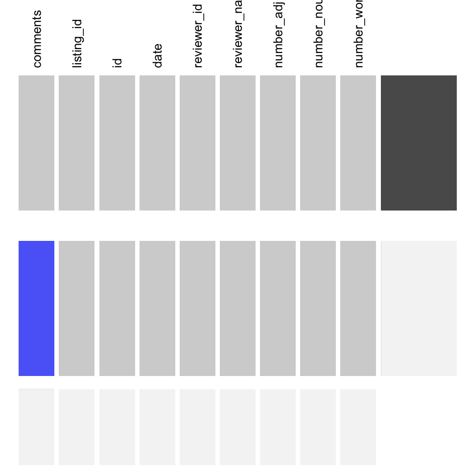

```r
library(extracat)
visna(reviewsPlus, sort='c')
```

```r
na_ind <- which(is.na(reviewsPlus$comments) == TRUE)
length(na_ind)
```

```
## [1] 870
```

```r
nrow(reviewsPlus)
```

```
## [1] 896208
```

```r
length(na_ind)/nrow(reviewsPlus)
```

```
## [1] 0.0009707568
```

### 3.2 Analysis of data quality - listing data of summary and review scores only

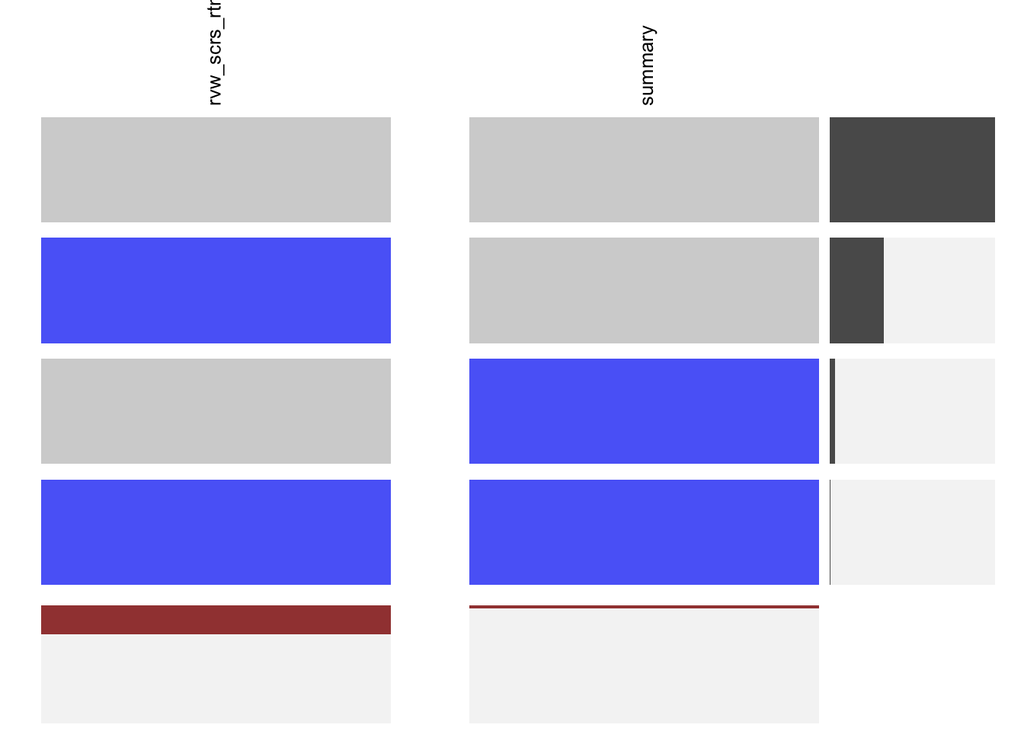

```r
library(dplyr)
ls <- listingsAll %>%
  select(summary, review_scores_rating)

visna(ls, sort='c')
```

# 4. Main Analysis (Exploratory Data Analysis)

## I.Overview

### 4.1.1 ratings distribution

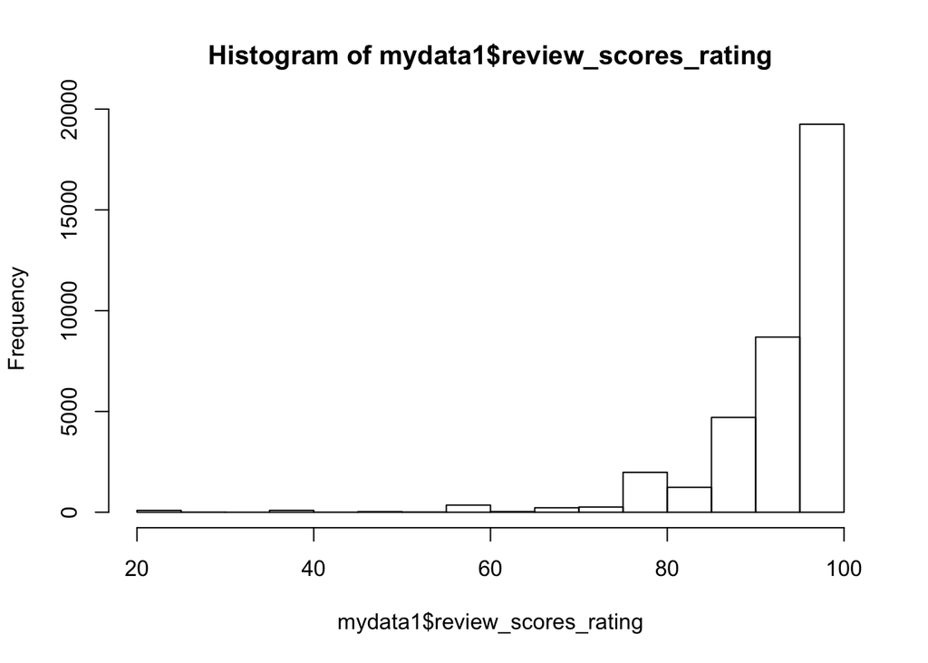

```r
library(dplyr)
mydata1 <- ls %>%
  dplyr::filter(!is.na(review_scores_rating))

hist(mydata1$review_scores_rating)
```

The purpose of this plot is to observe the distribution of review scores of each listing to come up with three rating categories. Category A indicates excellent listings with reviews scores from 90 to 100. Category B represent the good listings with reviews scores ranging between 75 to 90. Category C is a group of not-so-good listings where reviews scores are less than 75. It is interesting to notice that the majority of listings have high review scores.

## II. Listing summary

### 4.2.1 Which adjective words appear most frequently in listing summary?

```r
#install.packages("wordcloud")
#install.packages("RColorBrewer")
library(wordcloud)
library(RColorBrewer)

adj_s_all <- read.csv('adj_summary.csv', stringsAsFactors=FALSE,sep = "#")
adj_s_all$freq <- as.numeric(adj_s_all$freq)
```

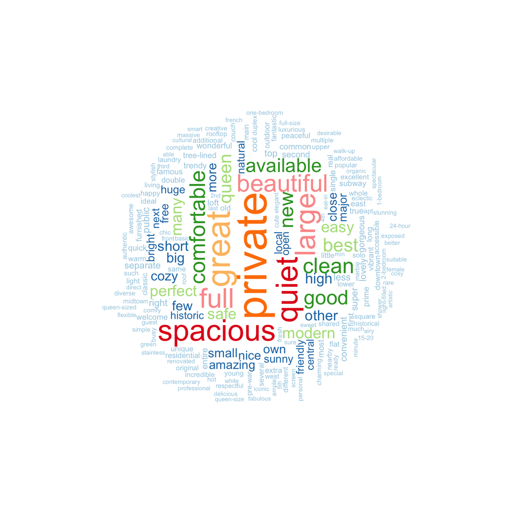

```r
#all
words_to_remove <- c('nan', 'll')

s1 <- adj_s_all %>%
  select(c("word", "freq")) %>%
  group_by(word) %>%
  summarize(freq=sum(freq)) %>%
  filter(!word %in% words_to_remove)

wordcloud(words = s1$word, freq = s1$freq,
                      min.freq = 1,
          max.words=200, random.order=FALSE, rot.per=0.35,
          colors=brewer.pal(8, "Paired"))
```

What aspects listing owners think are the most important and attractive to visitors can be shown by how they describe their spaces. As we can see from the wordcloud representing most common adjective words in the listing summary, “private” is the most frequently used words to describe a listing. It corresponds to the nature of Airbnb business model as it is based on the concept of sharing hosts’ personal housing with visitors. The other common words can be divided into two groups. First group, such “beautiful”, “great”, “comfortable”, expresses abstract ideas of the venue to stimulate reader’s imagination, while the second group, such as “new”, “quiet”, “spacious”, “large”, “clean”, gives readers more hints on the physical condition of the place to bring vivid pictures into user’s imagination.

### 4.2.2 Are words of summary in each rating category the same?

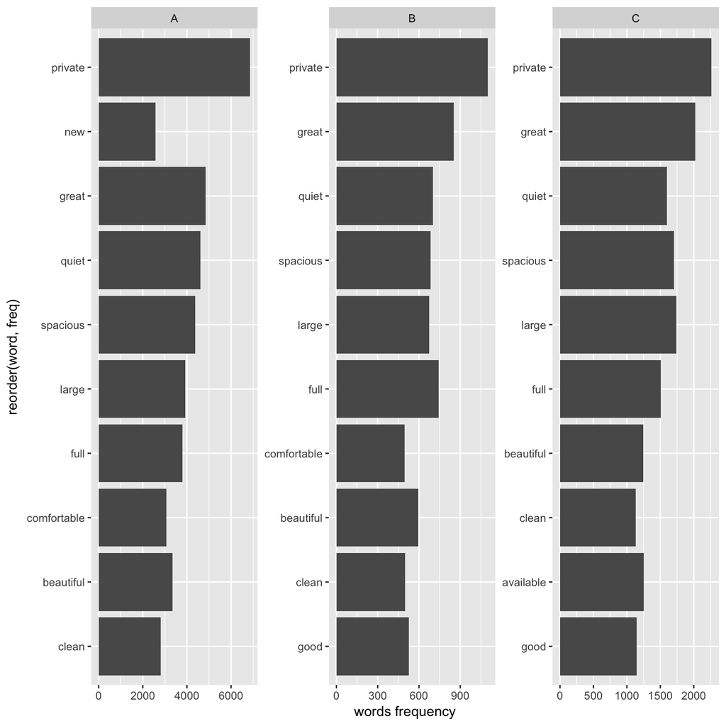

```r
library(ggplot2)

adj_s_all %>%
  group_by(category) %>%
  top_n(n=10, wt=freq) %>%
  ungroup() %>%
  ggplot(aes(reorder(word, freq), freq)) +
  geom_col(show.legend = FALSE) +
  facet_wrap(~category, scales = 'free') +
  labs(y = "words frequency",
       X="most frequent words") +
  coord_flip()
```

When listing owners describe their place, they would tend not only to portray their spaces to impress visitors but also be authentic to the real condition to certain extent. It turns out from our data exploration that these subtlties can be observed from the use of adjective words in their listing summary. We studied the summary from each rating groups and found interesting different usage of adjective words.

Top 10 common adjective words are very similar among the three rating categories like “great”, “private”, “beautiful”. Nevertheless, each group has one or two words different from the other group. Group A has the word “new”, which does not appear in group B or C. Group A and Group B both has the word “comfortable”, which is not present in group C. Both group B and C has the word “good”, which is not in the top list in group A. In group C, without “new” and “comfortable”, it has “available” instead. In conclusion, group A has “new” and “comfortable”, while group B has “comfortable” and “good”, and group C has “good” and “available”. The meaning of the three combinations already reveal the real condition of the listings to certain extent, which is confirmed by the rating groups of review scores.

## III. Amenities

### 4.3.1 What are the most frequent amenities words?

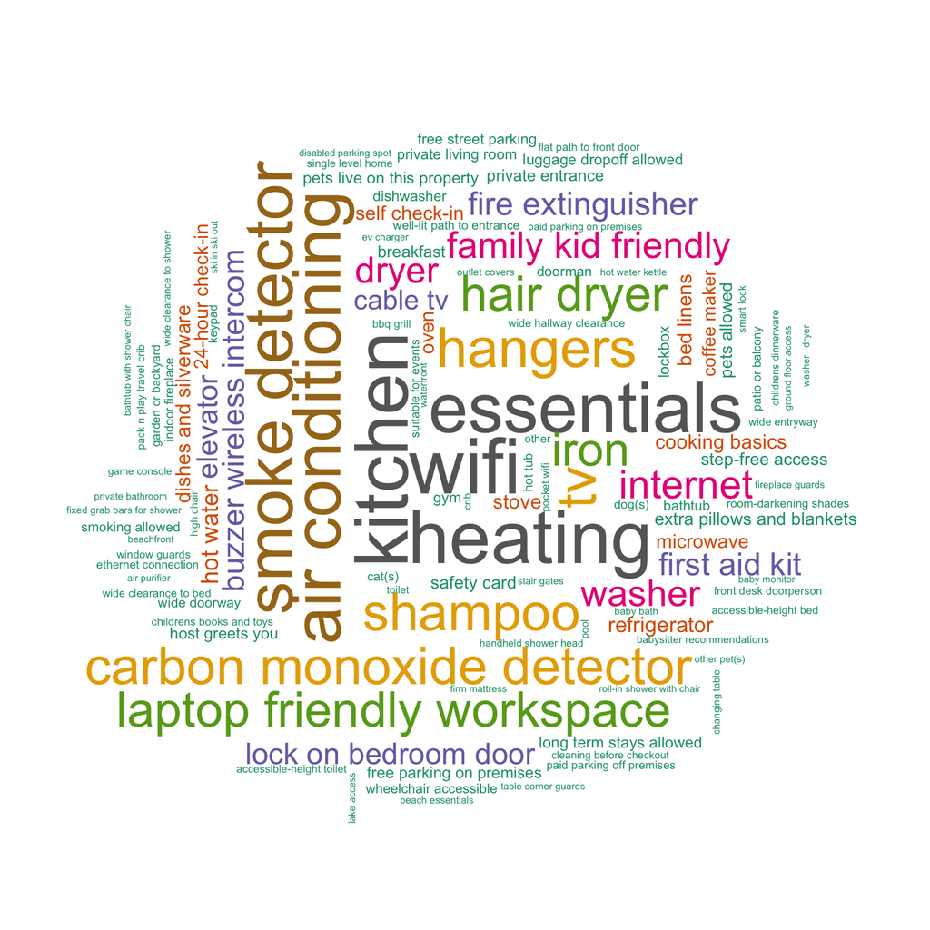

```r
amenities <- read.csv("amenities.csv", stringsAsFactors=FALSE,sep = "#")

amenities <- amenities[!startsWith(amenities$word, "translation missing"),]

wordcloud(words = amenities$word, freq = amenities$freq, min.freq = 1,
          max.words = 200, random.order=FALSE, rot.per=0.35,
          colors=brewer.pal(8, "Dark2"))
```

Apart from listing summary, amenities provide a clue how owners descrbe their spaces to make it more attractive to potential to visitors. Word frequency of amenities in listings are shown in the above wordcloud figure. When it comes to amenities, listing owners mostly focus on three areas basics, technology and safety.

- Basics: “essentials”, “hangers”, “shampoo”, “hair dryer”
- General Facility: “kitchen”, “heating”, “air conditioning”
- Technology: ’Wifi“,”laptop friendly workspace“,”internet"
- Safety: “smoke detector”, “carbon monoxide detector”, “fire extinguisher”.

Apparently, “kitchen”, “heating” and “air conditioning”, which provides comfort to a venue, are very often mentioned as part of the amenities provided by the listing. Safety is considered very important by the owners as those three words are comparably large as well. In terms of technology, “Wifi”, providing our connection to the world, is as essential as elements providing pyhsical comfort such as “kitchen”" or “heating”. Commonly mentioned items in basics include “hangers”, “hair dryer” and “shampoo”. These things are comparably easier to provide and it is nice to have them when visitors temporily stay at a place.

## IV. Reviews

### 4.4.1 Which words appear in high-rating or low-rating reviews?

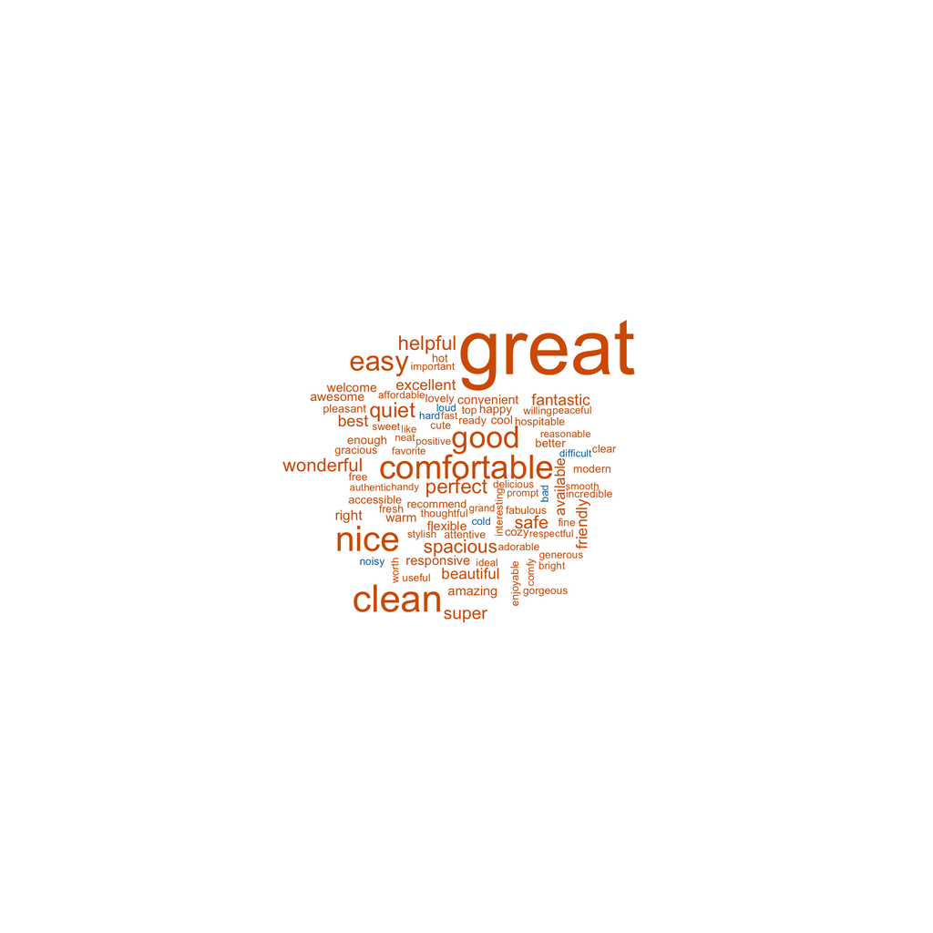

```r
library(tidytext)
library(reshape2)
library(wordcloud)

adj_r <- read.csv("adj_review.csv", stringsAsFactors=FALSE,sep = "#")
adj_r_A <- adj_r %>%
  filter(category == 'A') %>%
  top_n(n=200, wt=freq)

adj_r_C <- adj_r %>%
  filter(category == 'C') %>%
  top_n(n=200, wt=freq)

# The palette with black:
cbbPalette_s <- c("#0072B2", "#D55E00", "#CC79A7")

# words in high-rating reviews
df_A <- adj_r_A %>%
  inner_join(get_sentiments("bing"))

wordcloud::wordcloud(df_A$word, df_A$freq,
          ordered.colors=TRUE, max.words = 200,
          colors=cbbPalette_s[factor(df_A$sentiment)])
```

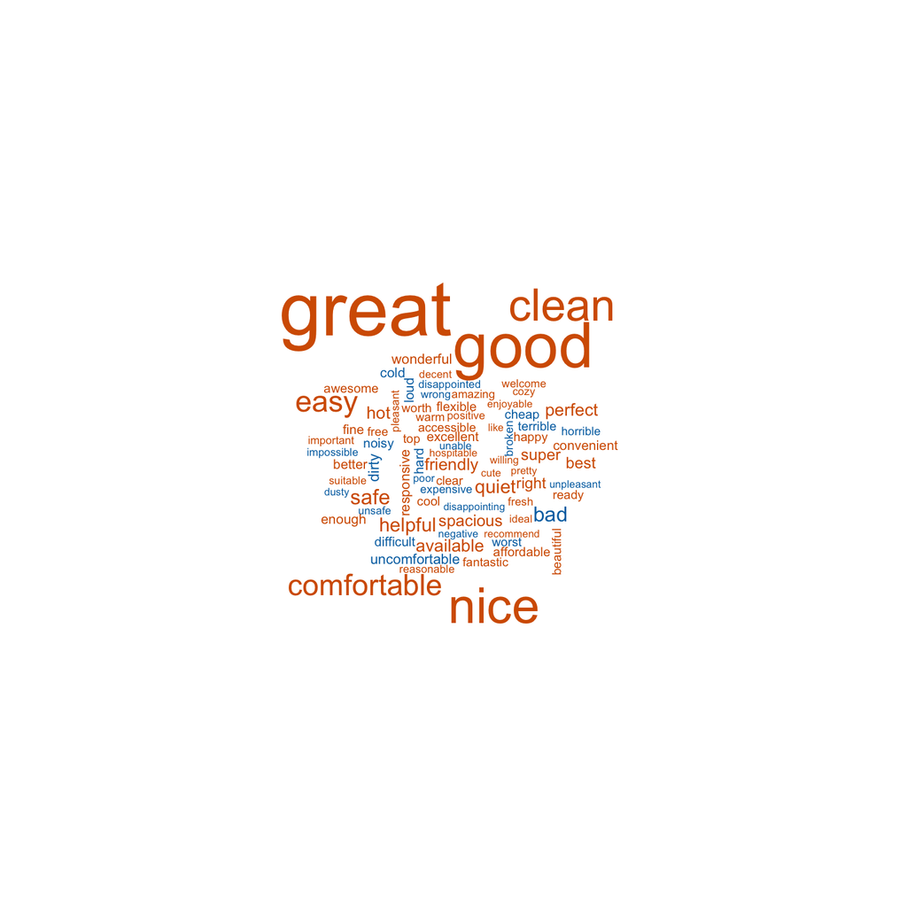

```r
# words in low-rating reviews
df_C <- adj_r_C %>%
  inner_join(get_sentiments("bing"))

wordcloud(df_C$word, df_C$freq,
          ordered.colors=TRUE, max.words = 200,
          colors=cbbPalette_s[factor(df_C$sentiment)])
```

Visitors’ experiences after staying in a listing can be revealed by sentiment analysis on the words in their reviews. We first did sentiment analysis on the adjective words of the reivews to identify words with positive or negative sentiments. As it is shown in the above two wordclouds, mostly positive words appeared in the reviews of listings with good ratings (Group A). As we moved to group C, although we could still see a few positive words in the reviews, more negative words appeared. Moreover, some words, such as “wonderful”, “super”, and “fantastic”, to express exceptionally good feelings or opinions became less obvious or disappeared in the group C wordcloud. The choice of color is vision deficiency friendly.

### 4.4.2 Is the length of reviews of each room-type or borough different?

```r
rp <- reviewsPlus[complete.cases(reviewsPlus),]

col_to_select <- c("id", "room_type", "neighbourhood_group_cleansed", 'rating_categ')
sc <- cleanedPlus %>%
  select(col_to_select)

gl <- rp %>%
  group_by(listing_id) %>%
  summarize(
    mean_adj=as.integer(mean(number_adj)),
    total_adj=sum(number_adj),
    mean_noun=as.integer(mean(number_noun)),
    total_noun=sum(number_noun),
    mean_words=as.integer(mean(number_words)),
    total_words=sum(number_words),
    review_counts=n(),
    perc_adj=total_adj/total_words,
    perc_noun=total_noun/total_words,
    perc_other=1-(perc_adj+perc_noun)
  ) %>%
  inner_join(sc, by = c("listing_id" = "id"))
```

Here we created columns required for analysis on reviews. In the following analysis on the length of reviews, we used the average words of reviews to represent this feature.

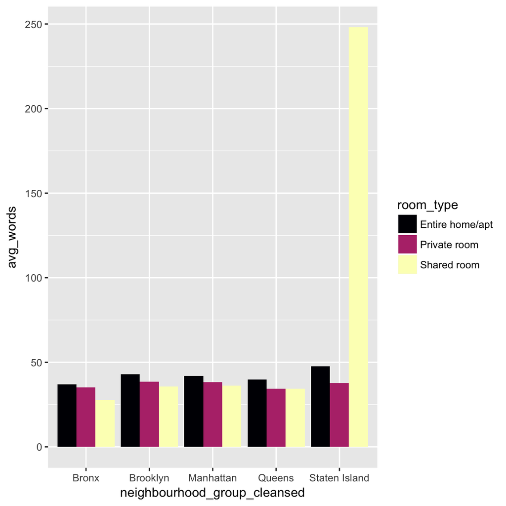

```r
#unloadNamespace("viridis")
#update.packages("viridis")
library(viridis)
library(dplyr)
library(ggplot2)
r1 <- gl %>%
  group_by(neighbourhood_group_cleansed, room_type) %>%
  dplyr::summarise(avg_words = mean(mean_words))

# Use position=position_dodge()
p <- ggplot(data=r1, aes(x=neighbourhood_group_cleansed,
                    y=avg_words, fill=room_type)) +
  geom_bar(stat="identity", position=position_dodge()) +
  scale_fill_viridis(discrete=TRUE, option="magma")

p
```

```r
# check the number of reviews of shared room in Staten Island
ss <- gl %>%
  filter(room_type == "Shared room") %>%
  filter(neighbourhood_group_cleansed == "Staten Island") %>%
  count()

ss
```

```
## # A tibble: 1 x 1
##       n
##   <int>
## 1     1
```

### 4.4.3 Is the length of review of each room-type or rating category different?

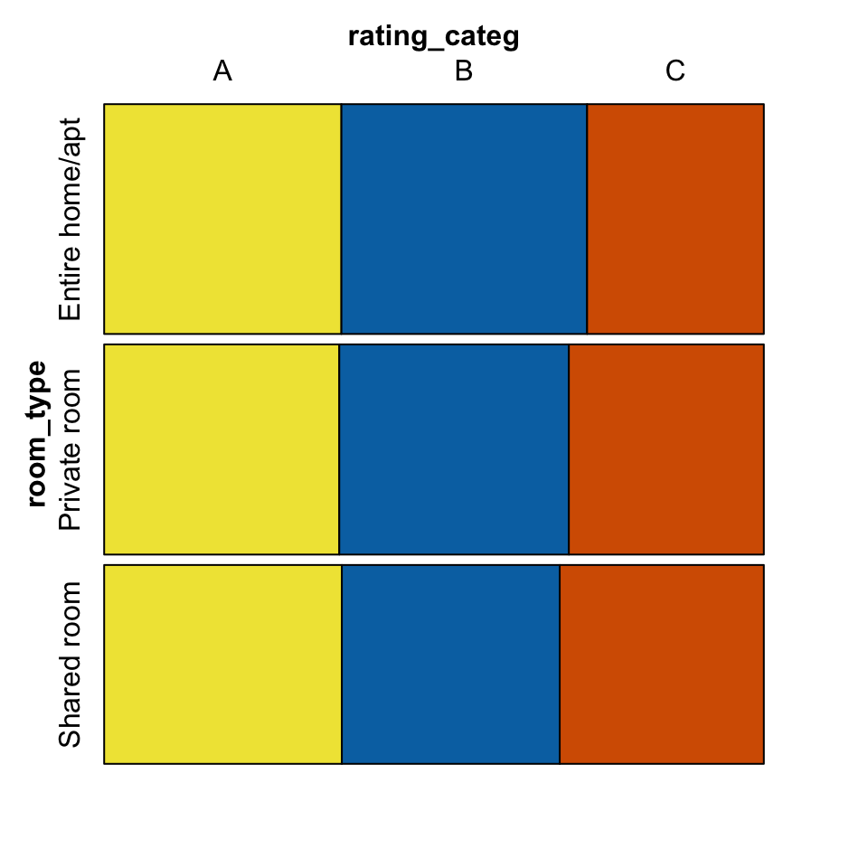

```r
library(grid)
r2 <- gl %>%
  group_by(rating_categ, room_type) %>%
  dplyr::summarise(avg_words = mean(mean_words))

# mosaic plot
r2$room_type <- as.factor(r2$room_type)
r2$rating_categ <- as.factor(r2$rating_categ)

r2t <- xtabs(avg_words ~ rating_categ+room_type,
                   r2)
cbbPalette <- c("#000000", "#E69F00", "#56B4E9", "#009E73", "#F0E442", "#0072B2", "#D55E00", "#CC79A7")

m2 <- vcd::mosaic(rating_categ~room_type, data=r2t,
                  gp = gpar(fill = cbbPalette[5:7]))
```

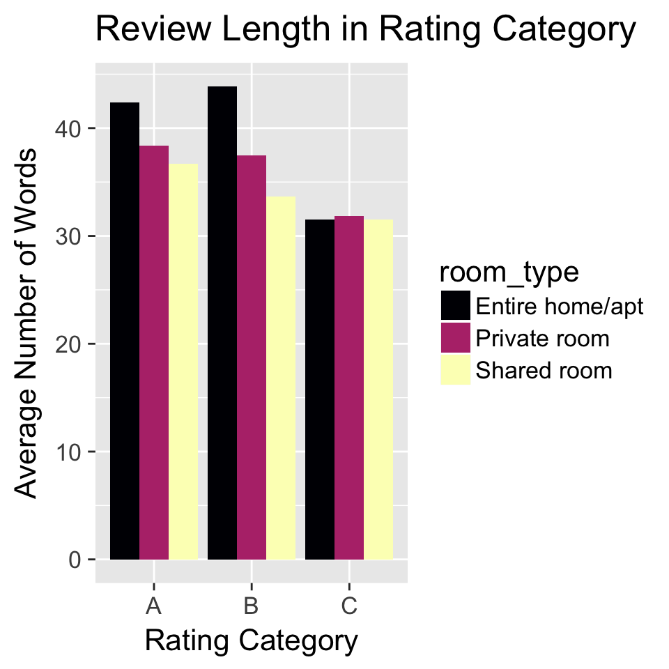

```r
# bar chart
p <- ggplot(data=r2, aes(x=rating_categ,
                    y=avg_words, fill=room_type)) +
geom_bar(stat="identity", position=position_dodge())+
scale_fill_viridis(discrete=TRUE, option="magma")+
  theme_grey(base_size = 16) +
  ggtitle("Review Length in Rating Category") +
  xlab("Rating Category") +
  ylab("Average Number of Words")

p
```

```r
ggsave(filename="images/ReviewsRatings.png", plot=p)
```

The length of reviews is a feature to observe how visitors would describe their good or not-so-good experiences and to see if difference exist among room types. In the mosaic plot, we can see there is an interaction between room type and rating category. While the number of words does not vary much for each rating category for shared room, it changes when people stay in entire home/apartment or private room with good experiences (rating group A or B). This observation reveals an interesing aspect of human behaviours showing that people are willing to put more efforts in terms of review length to talk about their good or wonderful experiences than average ones.

The change of review length is more prominent when we presented it using bar chart stratified by room types within each rating group. There is not difference among room types when people talk about not-so-satisfying experiences as shown in group C. In contrast, people use more words to describe their good and wonderful experiences (as shown in Group A and B) and, similar to the previous observation in section 4.4.2, the length of reviews increases from shared room, private room to entire home/apartment when visitors talk about their experiences in those difference venues. The choice of color is vision deficiency friendly.

### 4.4.4 Does the length of reviews become shorter or longer over time?

```r
rpg <- rp %>%
  left_join(sc, by = c("listing_id" = "id"))

rpg$date <- as.Date(rpg$date)
rpg$month <- as.Date(cut(rpg$date, breaks = "month"))
rpg$week <- as.Date(cut(rpg$date, breaks = "week"))
```

#### monthly changes over years

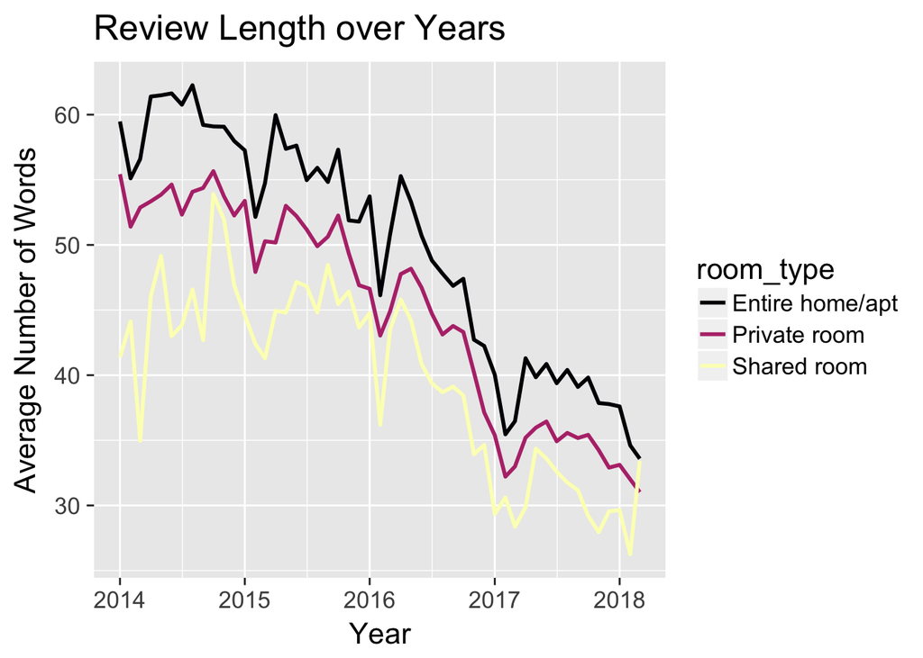

```r
r3 <- rpg %>%
  filter(date > "2014-01-01" & date <"2018-04-01") %>%
  group_by(month, room_type) %>%
  dplyr::summarise(avg_words = mean(number_words))

p <- ggplot(r3, aes(x=month, y=avg_words)) +
  geom_line(aes(color=room_type), size=1) +
  scale_color_viridis(discrete=TRUE, option="magma") +
  ggtitle("Review Length over Years") +
  xlab("Year") +
  ylab("Average Number of Words")+
  theme_grey(base_size = 16)
p
```

```r
ggsave(filename="images/ReviewsRoomtype.png", plot=p)
```

#### weekly changes in 2017

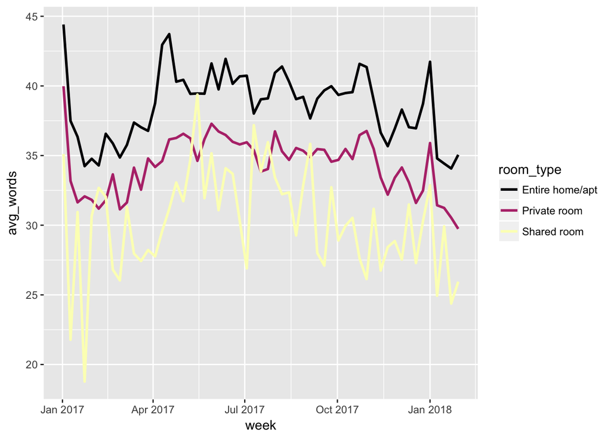

```r
r3 <- rpg %>%
  filter(date > "2017-01-01" & date <"2018-01-31") %>%
  group_by(week, room_type) %>%
  dplyr::summarise(avg_words = mean(number_words))

p <- ggplot(r3, aes(x=week, y=avg_words)) +
  geom_line(aes(color=room_type), size=1)

p + scale_color_viridis(discrete=TRUE, option="magma")
```

The second time series plot provides a quick closer look to see if any pattern exists within in a year when people wirte reviews in 2017. We can see that entire home/apartment and private room has similar patterns while shared room has slightly different one. Although some patterns can be observed in this plot, further exploration are required to get more insights. The choice of color is vision deficiency friendly.

## V. Text Analytics Summary

In summary, we have interesting findings in our text analytics on how listing owners portray their places (adjective words used in summary and description of amenities) and user behaviours in writting reviews (words to express sentiments on accommodation, efforts spent to write reviews based on room types or experiences in the venue, change of review length over time).